# Estudio de Asistentes al CTBA

Se realiza el join espacial con la base para tener información censal.

```r
ctbac <- st_join(ctba_st, censo)
```

```r
ctbac1 <- ctbac %>%
  group_by(POLY_ID) %>%
  summarise(qesp = n(),
            tasa_recur = mean(recur))

summary(ctbac1)
```

```
##     POLY_ID          qesp           tasa_recur              geometry
##  Min.   :  41   Min.   :  1.000   Min.   :0.0000   MULTIPOINT   :2752
##  1st Qu.: 891   1st Qu.:  3.000   1st Qu.:0.0000   POINT        : 418
##  Median :1699   Median :  6.000   Median :0.3550   epsg:4326    :   0
##  Mean   :1708   Mean   :  7.491   Mean   :0.3406   +proj=long...:   0
##  3rd Qu.:2524   3rd Qu.: 10.000   3rd Qu.:0.6000
##  Max.   :3590   Max.   :137.000   Max.   :1.0000
##  NA's   :1
```

```r
ctbac1 <- ctbac1 %>%
  as.data.frame() %>%
  select ( -geometry )

censoq <- left_join (censo, ctbac1)

censoq [is.na(censoq)] <- 0
```

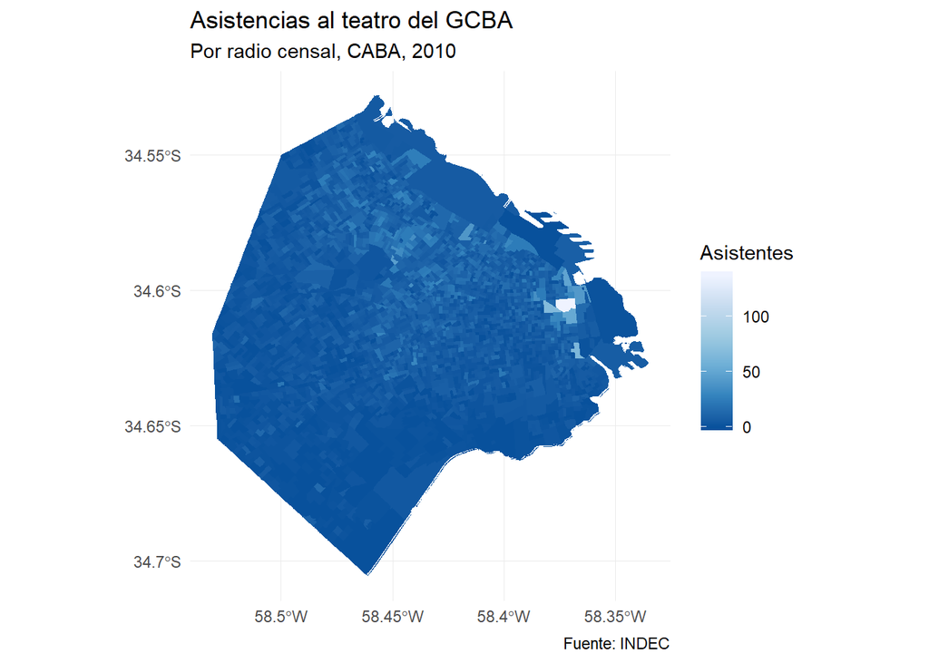

```r
ggplot() +
  geom_sf(data = censoq, aes (fill=  qesp), color=NA) +
  scale_fill_distiller() +
  labs(title="Asistencias al teatro del GCBA",
       subtitle= "Por radio censal, CABA, 2010",
       fill= "Asistentes",
       caption="Fuente: INDEC") +
  theme_minimal() +
  coord_sf(crs = st_crs(4326))
```

Como los radios son de distinto tamaño de población las normalizo por eso (densidad de espectadores: espectadores cada 100 habitantes).

```r
censoq <- mutate (censoq, dens_esp = qesp/POB10*100)

censoq [is.na(censoq)] <- 0

censoq$dens_esp [is.infinite (censoq$dens_esp)] <-0
```

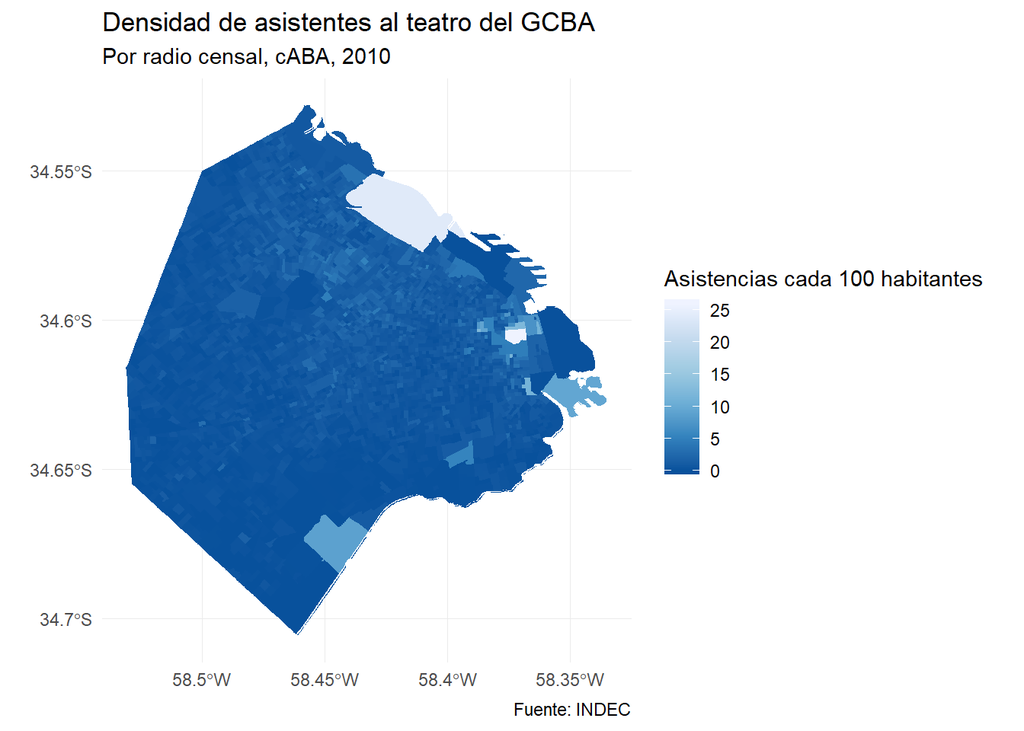

```r
ggplot() +
  geom_sf(data = censoq, aes (fill=  dens_esp), color=NA) +
  scale_fill_distiller() +
  labs(title="Densidad de asistentes al teatro del GCBA",
       subtitle= "Por radio censal, cABA, 2010",
       fill= "Asistencias cada 100 habitantes",
       caption="Fuente: INDEC") +
  theme_minimal()
```

Se observa que en general la densidad de asistentes aumenta hacia el norte de la ciudad, similar al sentido de población con secundario completo. Se estudia si hay alguna vinculación.

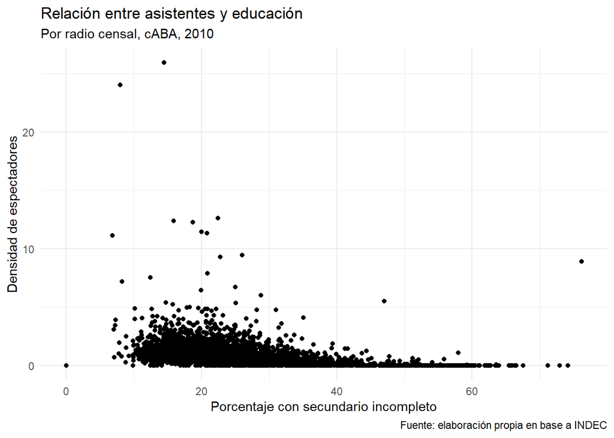

```r
ggplot(data = censoq) +
  geom_point(aes(x = Z_NEDU10, y = dens_esp))  +
  labs(title="Relación entre asistentes y educación",
       subtitle= "Por radio censal, cABA, 2010",
       fill= "Asistentes cada 100 habitantes",
       caption="Fuente: elaboración propia en base a INDEC",
       x="Porcentaje con secundario incompleto",
       y="Densidad de espectadores") +
  theme_minimal()
```

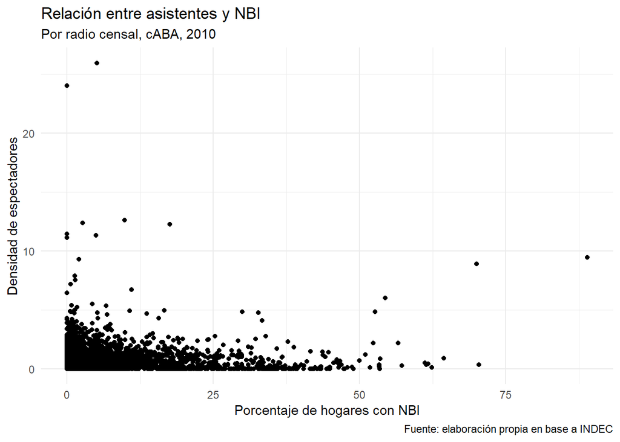

```r
ggplot(data = censoq) +
  geom_point(aes(x = Z_NBI10, y = dens_esp)) +
  labs(title="Relación entre asistentes y NBI",
       subtitle= "Por radio censal, cABA, 2010",
       fill= "Asistentes cada 100 habitantes",
       caption="Fuente: elaboración propia en base a INDEC",
       x="Porcentaje de hogares con NBI",
       y="Densidad de espectadores") +
  theme_minimal()
```

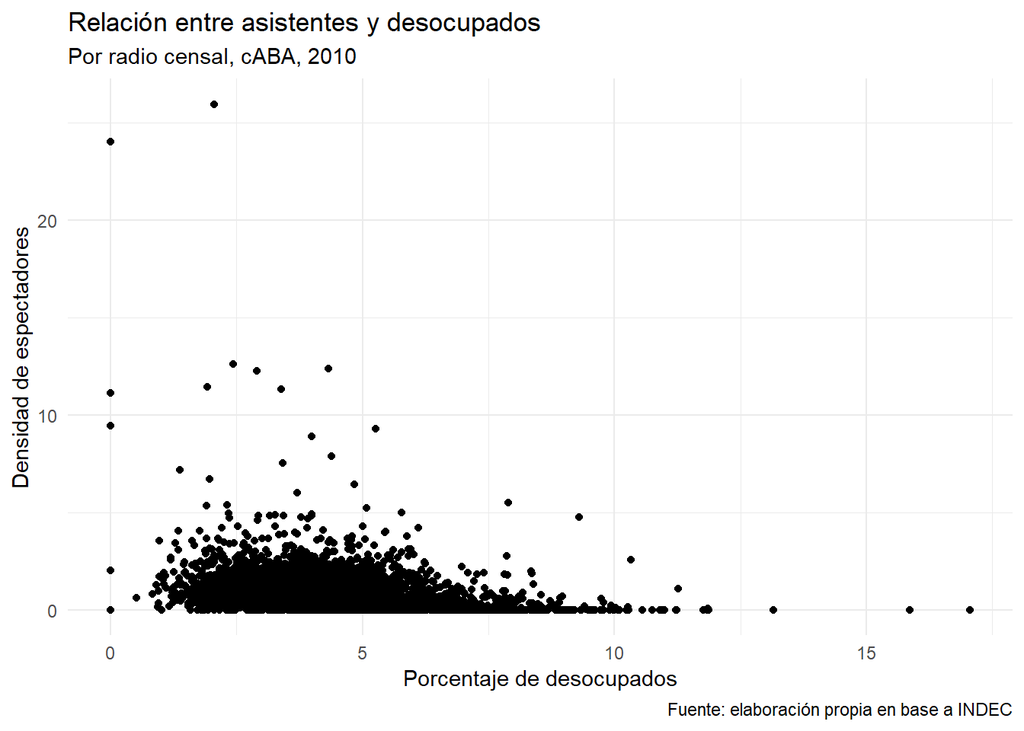

```r
ggplot(data = censoq) +
  geom_point(aes(x = Z_DESO10, y = dens_esp)) +
  labs(title="Relación entre asistentes y desocupados",
       subtitle= "Por radio censal, cABA, 2010",
       fill= "Asistentes cada 100 habitantes",
       caption="Fuente: elaboración propia en base a INDEC",
       x="Porcentaje de desocupados",
       y="Densidad de espectadores") +
  theme_minimal()
```

```r
mlqedu<- lm(dens_esp ~ Z_NEDU10, censoq)
summary(mlqedu)
```

```
##
## Call:
## lm(formula = dens_esp ~ Z_NEDU10, data = censoq)
##
## Residuals:
##     Min      1Q  Median      3Q     Max
## -1.8964 -0.5126 -0.2022  0.2622 24.6096
##
## Coefficients:
##              Estimate Std. Error t value Pr(>|t|)
## (Intercept)  1.896450   0.048375   39.20   <2e-16 ***
## Z_NEDU10    -0.038686   0.001761  -21.97   <2e-16 ***
## ---
## Signif. codes:  0 '***' 0.001 '**' 0.01 '*' 0.05 '.' 0.1 ' ' 1
##
## Residual standard error: 1.068 on 3591 degrees of freedom
## Multiple R-squared:  0.1185, Adjusted R-squared:  0.1183
## F-statistic: 482.8 on 1 and 3591 DF,  p-value: < 2.2e-16
```

```r
mlqnbi<- lm(dens_esp ~ Z_NBI10, censoq)
summary(mlqnbi)
```

```
##
## Call:
## lm(formula = dens_esp ~ Z_NBI10, data = censoq)
##
## Residuals:
##     Min      1Q  Median      3Q     Max
## -0.9628 -0.6295 -0.2478  0.3189 25.0294
##
## Coefficients:
##              Estimate Std. Error t value   Pr(>|t|)
## (Intercept)  0.962813   0.022516  42.760    < 2e-16 ***
## Z_NBI10     -0.008792   0.001967  -4.471 0.00000804 ***
## ---
## Signif. codes:  0 '***' 0.001 '**' 0.01 '*' 0.05 '.' 0.1 ' ' 1
##
## Residual standard error: 1.134 on 3591 degrees of freedom
## Multiple R-squared:  0.005535,   Adjusted R-squared:  0.005258
## F-statistic: 19.99 on 1 and 3591 DF,  p-value: 0.000008037
```

```r
mlqdes<- lm(dens_esp ~ Z_DESO10, censoq)
summary(mlqdes)
```

```
##
## Call:
## lm(formula = dens_esp ~ Z_DESO10, data = censoq)
##
## Residuals:
##     Min      1Q  Median      3Q     Max
## -1.5951 -0.5747 -0.2198  0.2778 24.6810
##
## Coefficients:
##             Estimate Std. Error t value Pr(>|t|)
## (Intercept)  1.59507    0.05066   31.48   <2e-16 ***
## Z_DESO10    -0.16045    0.01102  -14.55   <2e-16 ***
## ---
## Signif. codes:  0 '***' 0.001 '**' 0.01 '*' 0.05 '.' 0.1 ' ' 1
##
## Residual standard error: 1.105 on 3591 degrees of freedom
## Multiple R-squared:  0.0557, Adjusted R-squared:  0.05544
## F-statistic: 211.8 on 1 and 3591 DF,  p-value: < 2.2e-16
```

Analisando las regresiones entre densidad de asistentes cada 100 habitantes y las variables censales (porcentajes de población con secundario imcompleto, con nbi, descocupada -como aporximaciones al nivel socio económico) se observa que todas ellas son significativas, pero sin embargo tienen bajo poder predictivo en general (R cuadrado ajustado muy bajo). Según las regresiones: -por cada punto porcentual de aumento en la población con NBI, la cantidad de asistentes se reduce en 0.01; -por cada punto porcentual de aumento en la descoupación, la cantidad de asistentes se reduce en 0.16; -por cada punto porcentual de aumento en la población que no finalizó el secundario, la cantidad de asistentes se reduce en 0.04. Esto es, existe evidencia para afirmar que la asistencia al teatro está relacionada positivamente con mejores condiciones de vida, mayor nivel educativo y mejores condiciones laborales.

#### Relación con la accesibilidad cultural

Un último análisis refiere a la vinculación de la cantidad de asistentes por radio con las condiciones de accesibilidad cultural a espacios culturales de esos radios. El indice de accesibilidad cultural busca estblecer un parámetro comparable a todos los radios de la Capital en torno a las condiciones de accebilidad a espacios culturales. En ella, se conjugan la cercanía a espacios culturales, la cercanía a redes troncales de medios de trasnsporte y la caminabilidad de la zona (índice que calcula el GCBA) -más información en http://monitorculturalba.com.ar -. Lo que se busca explorar es si existe relación entre este índice y la cantidad de asistencias al teatro del GCBA por radio, lo que indicaría que las condiciones de accesibilidad a los espacios culturales efectivamente indicen en el consumo cultural.

```r
acc <- read_sf ('C:/Users/Claudia/Documents/R/GCBA Datos/Taller CABA/radios_con_barrio_y_acc2.shp')

summary(acc)
```

```
##   acc_activi          left_carto       left_left_       left_lef_1
##  Length:3576        Min.   :   1.0   Min.   :   1.0   Min.   :   1.0
##  Class :character   1st Qu.: 882.8   1st Qu.: 888.8   1st Qu.: 894.8
##  Mode  :character   Median :1776.5   Median :1782.5   Median :1788.5
##                     Mean   :1776.8   Mean   :1782.2   Mean   :1787.7
##                     3rd Qu.:2670.2   3rd Qu.:2676.2   3rd Qu.:2682.2
##                     Max.   :3564.0   Max.   :3558.0   Max.   :3555.0
##
##    acc_jun_ca       barrio            cartodb_id      co_frac_ra
##  Min.   :1.000   Length:3576        Min.   :   1.0   Length:3576
##  1st Qu.:1.000   Class :character   1st Qu.: 894.8   Class :character
##  Median :3.000   Mode  :character   Median :1788.5   Mode  :character
##  Mean   :2.753                      Mean   :1788.5
##  3rd Qu.:4.000                      3rd Qu.:2682.2
##  Max.   :4.000                      Max.   :3576.0
##  NA's   :1
##    acc_junio           acc_act         acc_espac        right_porc
##  Min.   :-0.02278   Min.   :0.1838   Min.   :0.1966   Min.   :0.00
##  1st Qu.: 0.65107   1st Qu.:0.7528   1st Qu.:0.8013   1st Qu.:1.90
##  Median : 0.75771   Median :0.8258   Median :0.8809   Median :2.44
##  Mean   : 0.73637   Mean   :0.8088   Mean   :0.8473   Mean   :2.53
##  3rd Qu.: 0.85270   3rd Qu.:0.8883   3rd Qu.:0.9303   3rd Qu.:3.07
##  Max.   : 0.99382   Max.   :0.9947   Max.   :0.9866   Max.   :6.73
##  NA's   :1          NA's   :1        NA's   :1        NA's   :6
##    right_po_1       right_po_2             geometry
##  Min.   : 0.000   Min.   : 0.00   MULTIPOLYGON :3576
##  1st Qu.: 2.470   1st Qu.:31.00   epsg:4326    :   0
##  Median : 3.150   Median :40.00   +proj=long...:   0
##  Mean   : 3.325   Mean   :39.71
##  3rd Qu.: 3.890   3rd Qu.:51.00
##  Max.   :16.880   Max.   :80.00
##  NA's   :6        NA's   :6
```

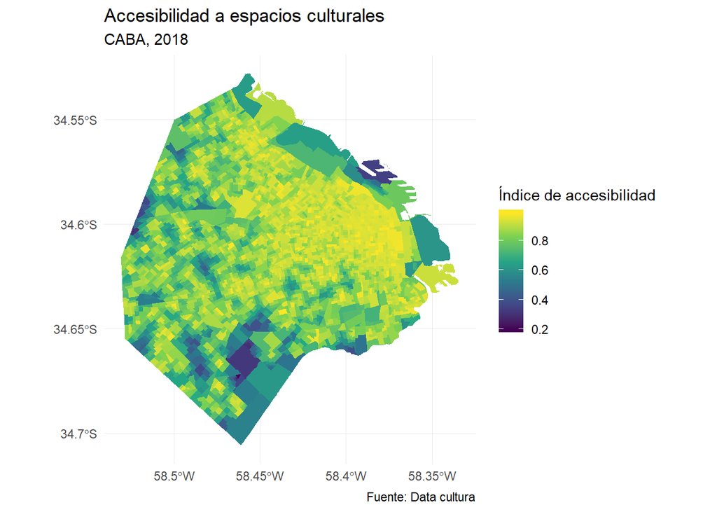

```r
ggplot() +
  geom_sf(data = acc, aes (fill=  acc_espac), color=NA) +
  scale_fill_viridis_c() +
  labs(title="Accesibilidad a espacios culturales",
       subtitle= "CABA, 2018",
       fill= "Índice de accesibilidad",
       caption="Fuente: Data cultura") +
  theme_minimal()+
  coord_sf(crs = st_crs(4326))
```

Se observa que el índice de accesibilidad encuentra sus valores más altos en las zonas este y norte de la Capital, y sidminuye a medida que se aleja de ese foco.

```r
ctbac<- mutate (ctbac, d_esp = 1/POB10)

ctbaacc <- st_join(ctbac, acc)
```

```r
ctbaacc1 <- ctbaacc %>%
  group_by(co_frac_ra) %>%
  summarise(qesp = n(),
            POB10= mean(POB10))

summary(ctbaacc1)
```

```
##   co_frac_ra             qesp             POB10
##  Length:3132        Min.   :  1.000   Min.   :  25.0
##  Class :character   1st Qu.:  3.000   1st Qu.: 690.1
##  Mode  :character   Median :  6.000   Median : 800.5
##                     Mean   :  7.743   Mean   : 816.3
##                     3rd Qu.: 10.000   3rd Qu.: 922.0
##                     Max.   :408.000   Max.   :3385.0
##                                       NA's   :1
##           geometry
##  MULTIPOINT   :2697
##  POINT        : 435
##  epsg:4326    :   0
##  +proj=long...:   0
##
##
##
```

```r
ctbaacc1 <- ctbaacc1 %>%
  as.data.frame() %>%
  select ( -geometry )

ctbaacc1 <- mutate (ctbaacc1, dens_esp = qesp/POB10*100)

accq <- left_join (acc, ctbaacc1)

accq [is.na(accq)] <- 0 #por si es dividido 0
```

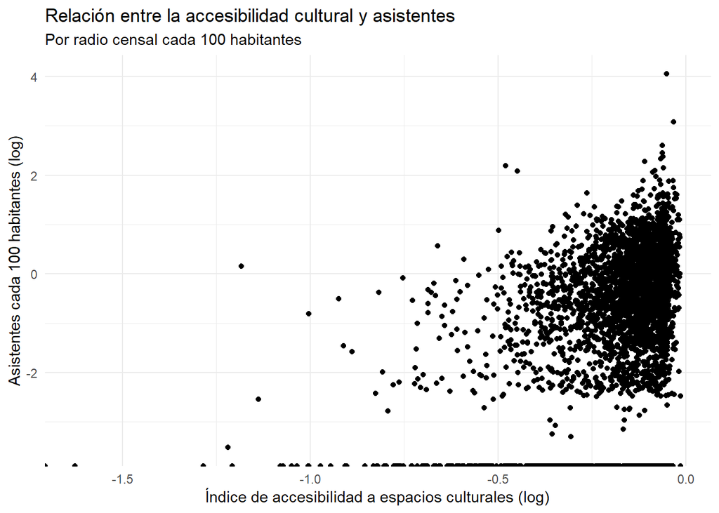

```r
ggplot(data = accq) +
  geom_point(aes(x = log(acc_espac), y = log(dens_esp))) +
    labs(title = "Relación entre la accesibilidad cultural y asistentes",
         subtitle = "Por radio censal cada 100 habitantes",
         x= "Índice de accesibilidad a espacios culturales (log)",
         y = "Asistentes cada 100 habitantes (log)") +
  theme_minimal()
```

```r
accq <- accq %>%
  as.data.frame () %>%
  mutate (logdens = log(dens_esp)) %>%
  mutate (logacc = log(acc_espac))

accq [is.na(accq)] <- 0

accq$logdens [is.infinite(accq$logdens)] <- -3
accq$logacc [is.infinite(accq$logacc)] <- -3

mlqacc<- lm(logdens ~ logacc, accq)
summary(mlqacc)
```

```
##
## Call:
## lm(formula = logdens ~ logacc, data = accq)
##
## Residuals:
##     Min      1Q  Median      3Q     Max
## -2.7878 -0.7002  0.1613  0.7918  5.8272
##
## Coefficients:
##             Estimate Std. Error t value Pr(>|t|)
## (Intercept) -0.17318    0.02862   -6.05 1.59e-09 ***
## logacc       2.88468    0.11971   24.10  < 2e-16 ***
## ---
## Signif. codes:  0 '***' 0.001 '**' 0.01 '*' 0.05 '.' 0.1 ' ' 1
##
## Residual standard error: 1.151 on 3574 degrees of freedom
## Multiple R-squared:  0.1398, Adjusted R-squared:  0.1395
## F-statistic: 580.6 on 1 and 3574 DF,  p-value: < 2.2e-16
```

Según los resultados de la regresión, la accesibilidad cultural a los espacios culturales es una variable muy explicativa de la canitdad de asistentes por radio cada 100 habitantes. Nuevamente, el valor predictivo del modelo es bajo (0.14), pero se puede estimar que por cada punto porcentual que aumenta el índice de accesibilidad, aumenta un 2.88% la cantidad de espectadores por habitantes del radio censal.

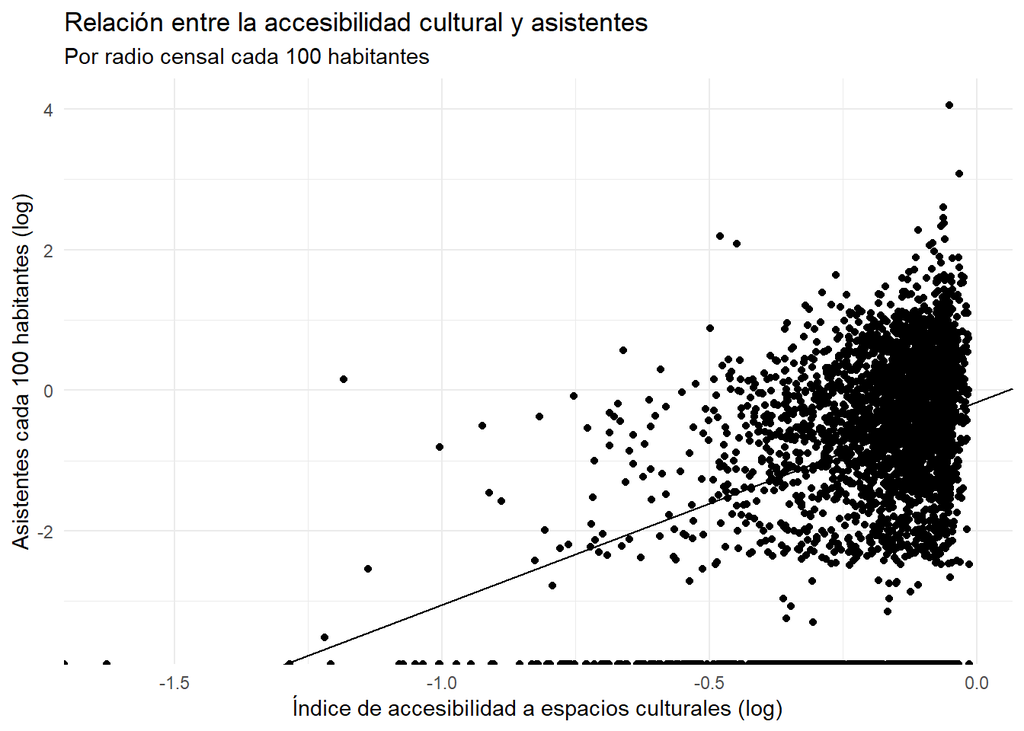

```r
ggplot(data = accq) +
  geom_point(aes(x = log(acc_espac), y = log(dens_esp))) +
    labs(title = "Relación entre la accesibilidad cultural y asistentes",
         subtitle = "Por radio censal cada 100 habitantes",
         x= "Índice de accesibilidad a espacios culturales (log)",
         y = "Asistentes cada 100 habitantes (log)") +
  theme_minimal() +
  geom_abline(aes(intercept = -0.17318 , slope = 2.88468  ))
```